# 第3回 データを整えて、値段を付ける

前処理：外れ値・欠けた値・文字の列・目盛り

# 導入

## 前回までにやったこと

- 自転車シェアの台数を、1本の式で当てた
- 訓練とテストに分けて、まだ見ていないデータで実力を測った

## でも、データはきれいだった

- 欠けた値もなく、列の型もそろった、整えられたデータ
- 現場のデータは、そうはいかない

## 場面が変わる

- あなたは、民泊の新しいホスト
- 自分のマンションの一室を、貸切で出したい

## 今日の問い

1泊いくらの値段を付ければいいか。似た部屋の料金を手がかりに答えます。

## 今日のコードの書き方

- 同じ計算を何度も書く代わりに、関数（`def`）にまとめる
- 関数の引数が入力、`return`の後ろが出力
- 小さな関数を組み合わせて、前処理を1つにまとめる

## この問いに、どう近づくか

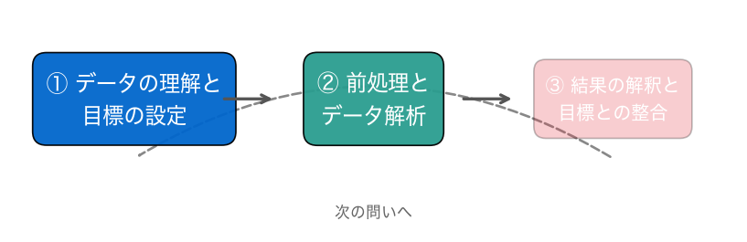

①データを知り、②前処理で整える。今日はここが中心です。

# 0. 設定

## やってみよう：0節

- 第3回のノートを開き、ドライブにコピーする
- 0節の設定のセルを実行し、「セットアップ完了」を確かめる

動画の人は、ここで一時停止。

# 1. どの部屋を手がかりにするか

## まず、どんな部屋があるか見る

- 値段は、似た部屋の料金を手がかりに付ける
- その前に、どんな部屋が並んでいるかを確かめる

## お手本：料金の形を見る

```python
# データはこのリポジトリから読み込む
DATA_DIR = ('https://raw.githubusercontent.com/k0heiun0/'
            'applied_exercise_preview/main/shared/data')
df = pd.read_csv(f'{DATA_DIR}/airbnb_tokyo.csv')
print(len(df), '件')
print(df['price'].describe().round(0))
plt.hist(df['price'], bins=100, range=(0, 300000), color='#0066cc')
plt.xlabel('1泊の料金（円）'); plt.ylabel('部屋の数')
plt.show()
```

- 役割：データを読み込み、料金の要約とヒストグラムを出す
- `range=(0, 300000)`は、図に描く範囲（0〜30万円）を決める引数

## おさらい：条件で絞る

```python
df[df['price'] <= 100000]      # 10万円以下の部屋だけ
```

- `df[ ]`にTrue/Falseの並びを入れると、Trueの行だけが残る

## 変えてみる：貸切の部屋に絞る

```python
df = df[df['price'] <= 100000]                  # 10万円以下の部屋だけ
print(df.groupby('room_type')['price'].agg(['median', 'count']))
df = df[df['room_type'] == 'Entire home/apt']   # 貸切の部屋だけ
df = df.reset_index(drop=True)                  # 行の番号を振り直す
print(len(df), '件')
```

## やってみよう：1節

- 1節のお手本と「変えてみる」のセルを実行する
- 料金は、どんな形でばらついているか？

動画の人は、ここで一時停止。

## 答え合わせ：料金の形は？

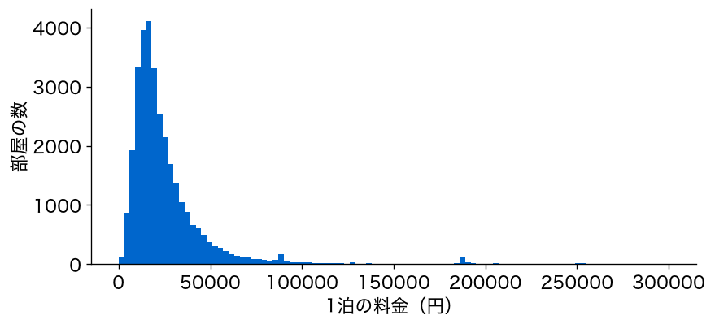

- 2万円あたりに山が1つ。右に長い尾が伸びる（図は30万円まで）

## 最大は、545万円

```
count      32361.0
mean       31085.0
std        65610.0
min         1514.0
25%        13466.0
50%        19578.0
75%        30430.0
max      5449800.0
```

- 中央値は約2万円なのに、最大は545万円。尾は図の外まで続く

## 外してよいのか？

- 1泊数十万〜数百万円の部屋は、一棟貸しの大きな家や、特定の日の値上げなどが考えられる

## 別の市場と考える

- ふつうの部屋とは別の市場と考えたほうがよい。今日の目標の手がかりにならない

## 外すときの約束

- 外す理由を、目標から説明できること
- どこで線を引いたかを、書き残すこと

## 1泊10万円以下に絞る

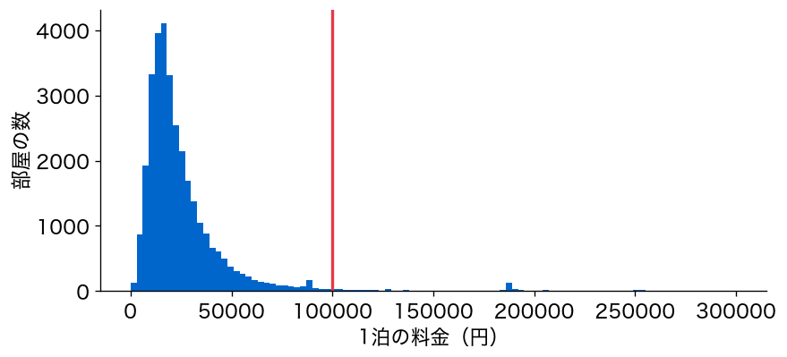

- 赤線より右の、902件（2.8%）を外す

## 部屋のタイプで、水準が違う

```
                  median  count
room_type
Entire home/apt  20092.0  26433
Hotel room       10875.0    110
Private room     14580.0   4605
Shared room       3424.0    311
```

- 貸切は約2万円、相部屋は3千円台。別の商品

## だから、貸切だけに絞る

```
26433 件
```

- 目標に照らして使う行を決めるのも、前処理
- 残ったのは、26,433件

## 先に、訓練とテストに分ける

```python
tr, te = train_test_split(df, test_size=0.2, random_state=42)
y_tr = tr['price'].values
y_te = te['price'].values
print(len(tr), len(te))
```

- このあとの前処理は、すべて訓練データだけを見て決める

# 2. 物差しを、関数にまとめる

## 部屋は決まった。どう測る？

- 1節で、貸切の26,433件に絞り、訓練とテストに分けた

## 何度も測る

- 今日は、整えるたびに「何円外れたか」を何度も測る
- 同じ計算を毎回書くのは、大変

## お手本：外れ幅を関数にする

```python
def mae(y, pred):          # 外れ幅の平均（第1回と同じ物差し）
    return round(np.abs(y - pred).mean())
```

- 役割：実際の料金と予測から、外れ幅の平均（円）を出す

## defの読み方

```python
def mae(y, pred):          # 外れ幅の平均（第1回と同じ物差し）
    return round(np.abs(y - pred).mean())
```

- `def 名前(引数):`で関数を作る。中身は字下げした行
- 引数（`y`・`pred`）が入力、`return`の後ろが戻り値（出力）

## 役割・入力・出力に、名前を付けた

- これまで「役割・入力・出力」で読んできたかたまり
- それに名前を付けて、何度も呼べるようにしたものが関数

## 作っただけでは、何も出ない

- `def`のセルを実行しても、何も表示されない
- 関数を作っただけ。使うには、呼び出す

## 変えてみる：関数を呼び出す

```python
base = np.median(y_tr)          # 答え：どの部屋も、訓練の中央値
print(base)
print(mae(y_te, base))          # 関数を呼び出す
```

- 名前にかっこを付け、引数を渡す

## やってみよう：2節

- 2節のお手本と「変えてみる」のセルを実行する
- 何も工夫せずに答えると、何円外れるか？

動画の人は、ここで一時停止。

## 答え合わせ：基準は10,756円

```
20170.0
10756
```

- どの部屋も約2万円と答えたときの外れ幅は、平均10,756円
- この10,756円を、基準にする

# 3. 欠けた値を、落とすか補うか

## 基準は10,756円。ここから整える

- 何も工夫しない答えの外れ幅が、基準になった
- まず、欠けた値から整える

## 数の列に、空欄がある

- 寝室数、ベッド数、バスルーム数……ところどころ欠けている
- どの列が、どれだけ欠けているか？

## TODO①：欠測の数と割合

```python
# TODO: 列ごとの欠測の数と、割合（%）を表示する
# ヒント: df.isna().sum() と df.isna().mean() * 100
...
```

- `isna()`は、欠けているかをTrue/Falseで表す

## 欠ける理由は？

- 欠け方には、理由があることがある
- 理由を確かめてから、どう扱うか決める

## お手本：欠けたバスルーム数を見る

```python
miss = tr['bathrooms'].isna()      # バスルーム数が欠けた部屋は True
print(miss.sum(), '件')
print(tr[miss]['bathrooms_text'].value_counts().head())
```

- 役割：バスルーム数が欠けた部屋の、文字の列`bathrooms_text`を数える
- `value_counts()`は、中身ごとの件数を多い順に並べる

## 変えてみる：文字から数を戻す

```python
def bath_num(text):            # '1.5 baths' → 1.5
    if text == 'Half-bath':
        return 0.5
    return float(text.split(' ')[0])

def fill_bath(d):              # 欠けたバスルーム数を、文字から戻す
    from_text = d['bathrooms_text'].map(bath_num)
    return d['bathrooms'].fillna(from_text)

tr = tr.assign(bathrooms=fill_bath(tr))
te = te.assign(bathrooms=fill_bath(te))
df = df.assign(bathrooms=fill_bath(df))
print(tr['bathrooms'].isna().sum(), te['bathrooms'].isna().sum())
```

## splitで切って、floatで数に

```python
    return float(text.split(' ')[0])
```

- `'1.5 baths'.split(' ')`は、空白で切って`['1.5', 'baths']`
- `[0]`で最初の`'1.5'`を取り、`float( )`で小数の数1.5にする
- `'Half-bath'`だけは数がないので、`if`で0.5を返す

## mapは、1つずつ関数に通す

```python
    from_text = d['bathrooms_text'].map(bath_num)
    return d['bathrooms'].fillna(from_text)
```

- `map(関数)`：列の中身を1つずつ関数に通した列を返す
- `fillna(列)`：欠けたマスだけを、同じ行の値で埋める

## どの表に当ててもよい

```python
tr = tr.assign(bathrooms=fill_bath(tr))
te = te.assign(bathrooms=fill_bath(te))
df = df.assign(bathrooms=fill_bath(df))
```

- `assign(列名=値)`は、その列を置き換えた新しい表を返す
- その部屋の文字だけを読む。訓練・テスト・全体のどれに当ててもよい

## 変えてみる：寝室の欠けた部屋

```python
miss_bed = tr['bedrooms'].isna()   # 寝室数が欠けた部屋は True
print(tr.groupby(miss_bed)[['accommodates', 'price']].median())
print('寝室数が0の部屋:', (tr['bedrooms'] == 0).sum(), '件')
```

- 欠けた部屋と欠けていない部屋で、定員と料金の中央値を比べる

## やってみよう：3節の前半

- TODO①：列ごとの欠測の数と割合を出す
- お手本と、2つの「変えてみる」のセルを実行する

動画の人は、ここで一時停止。

## 答え合わせ：TODO①

```
                      欠測の数    割合
accommodates             0   0.0
bedrooms              1284   4.9
beds                  1041   3.9
bathrooms             1656   6.3
minimum_nights           3   0.0
availability_365         0   0.0
number_of_reviews        0   0.0
host_listings_count      0   0.0
review_scores_rating  2899  11.0
```

- バスルーム6.3%、寝室4.9%、ベッド3.9%、レビューの点数11%（文字の列は欠けなし）

## レビューの点数は、なぜ欠けた？

```
点数が欠けている  False  True
レビュー0件
False     23534      0
True          0   2899
```

- 点数が欠けた部屋は、ぴったりレビューが0件の部屋

## 理由のある欠け方は、埋めない

- まだ誰も泊まっていないから、点数が付きようがない
- 平均で埋めると「まだ誰も泊まっていない」という情報が消える
- 今日は、点数の列を使わない

## 答え合わせ：欠けたバスルーム数

```
1276 件
bathrooms_text
1 bath       1036
1.5 baths      87
2 baths        75
0 baths        40
Half-bath      13
Name: count, dtype: int64
```

- 欠けた1,276件は、どれも`bathrooms_text`に数が書いてある

## 別の列から、戻せる欠けもある

```
0 0
```

- 中央値で推測するより、文字から本当の値を戻すほうが確か
- 戻したあとの欠けは、訓練もテストも0件

## 答え合わせ：寝室数が欠けた部屋

```
          accommodates    price
bedrooms
False              4.0  20464.0
True               2.0  15960.0
寝室数が0の部屋: 0 件
```

- 欠けた部屋（True）は、定員2人・15,960円。欠けていない部屋は4人・20,464円

## 寝室数0の部屋は、1件もない

```
          accommodates    price
bedrooms
False              4.0  20464.0
True               2.0  15960.0
寝室数が0の部屋: 0 件
```

- ワンルームが「0」ではなく、欠けとして入ったのかもしれない
- これも、理由のある欠け方の疑いがある

## 欠けていた印を残す

```python
tr = tr.assign(bedrooms_missing=tr['bedrooms'].isna().astype(int))
te = te.assign(bedrooms_missing=te['bedrooms'].isna().astype(int))
df = df.assign(bedrooms_missing=df['bedrooms'].isna().astype(int))
print(tr['bedrooms_missing'].sum(), '件に印')
```

- 欠けていたら1、いなければ0。`astype(int)`でTrue/Falseを1/0に
- 補った値（推測）の部屋を、式が区別できる

## 行を落とすか、補うか

- 行を落とす：欠けた部屋を丸ごと使わない。手軽だが、データが減る
- 補う：欠けた値を、訓練の中央値などで埋める。データは減らない

## 補った値は、推測にすぎない

- 中央値は、極端な値に引きずられにくい
- でも、寝室数が欠けた小さな部屋に「寝室1」は、ずれているかもしれない
- だから、印の列を残しておく

## お手本：訓練の中央値で補う

```python
num = ['accommodates', 'bedrooms', 'beds', 'bathrooms',
       'minimum_nights', 'availability_365', 'number_of_reviews',
       'host_listings_count', 'bedrooms_missing']
med = tr[num].median()                 # 補う値は、訓練だけで決める
X_tr = tr[num].fillna(med).values
X_te = te[num].fillna(med).values      # テストも、訓練の中央値で
print(med)
```

## fillnaは、欠けた値を置き換える

```python
X_tr = tr[num].fillna(med).values
```

- `fillna(値)`は、欠けたマスをその値で置き換える
- 列ごとの中央値を渡すと、列ごとにその値で埋める

## 変えてみる：落とすvs補う

```python
ok = tr[num].notna().all(axis=1).values      # 欠けのない行は True
m_drop = LinearRegression().fit(tr[num].values[ok], y_tr[ok])
m_num = LinearRegression().fit(X_tr, y_tr)
print('落とした:', mae(y_te, m_drop.predict(X_te)), '円')
print('補った  :', mae(y_te, m_num.predict(X_te)), '円')
print('使えた行:', ok.sum(), '/', len(ok))
print('印の係数:', round(m_num.coef_[-1]), '円')
```

- 2節の`mae`を、2回呼ぶだけ

## axis=1は、1行ずつ

```python
ok = tr[num].notna().all(axis=1).values      # 欠けのない行は True
```

- `notna()`は欠けていないマスがTrue。`.all(axis=1)`は1行ずつ、全部Trueかを調べる
- `axis=1`は行ごと（列をまたぐ）。5節の`axis=0`は列ごと（行をまたぐ）

## [-1] は、後ろから1つ目

```python
print('印の係数:', round(m_num.coef_[-1]), '円')
```

- `coef_`は、列ごとの係数の並び
- `[-1]`で最後の1つ。ここでは、印の列`bedrooms_missing`の係数

## SimpleImputerも、同じ中央値

```python
imp = SimpleImputer(strategy='median').fit(tr[num])
print(imp.statistics_)                          # 上の med と同じか？
```

- scikit-learnの、欠けを補う道具。訓練で`fit`すると、`statistics_`に中央値が入る

## やってみよう：3節の後半

- 印のセル、お手本、「変えてみる」、SimpleImputerのセルを実行する
- 落とすのと補うのでは、どちらが当たるか？

動画の人は、ここで一時停止。

## 答え合わせ：訓練の中央値

```
accommodates             4.0
bedrooms                 1.0
beds                     2.0
bathrooms                1.0
minimum_nights           1.0
availability_365       219.0
number_of_reviews       21.0
host_listings_count     16.0
bedrooms_missing         0.0
```

- 寝室1、ベッド2、バスルーム1。印の列は0（印の列そのものに欠けはない）

## 答え合わせ：落とすvs補う

```
落とした: 8822 円
補った  : 8807 円
使えた行: 19321 / 21146
印の係数: -140 円
```

- 外れ幅は、落とすと8,822円、補うと8,807円
- どちらも、基準から2千円近く縮んだ

## 補うほうが、使いやすい

```
落とした: 8822 円
補った  : 8807 円
使えた行: 19321 / 21146
印の係数: -140 円
```

- 落とすと、訓練の8.6%（1,825件）を捨てる
- ホストが寝室数を書き忘れても、補うやり方なら答えを返せる

## 印の係数は、−140円

```
落とした: 8822 円
補った  : 8807 円
使えた行: 19321 / 21146
印の係数: -140 円
```

- 定員などがそろえば、欠けていた部屋だけが特に安いわけではない
- 安く見えたのは、主に定員が小さいから。このデータでは、補っても大きな問題はない

## 答え合わせ：SimpleImputer

```
[  4.   1.   2.   1.   1. 219.  21.  16.   0.]
```

- 上の`med`と同じ値。課題では、この道具で平均でも補ってみる

# 4. 文字の列に、番号を振ってよいか

## 数の列は整った。残るは文字の列

- 3節で欠けを補い、式の外れ幅は8,807円まで縮んだ
- まだ使っていない手がかりに、地区（文字の列）がある

## 地区で、料金は違う？

- 同じ貸切でも、地区によって料金は違いそう
- 地区ごとの料金を見てみる

## TODO②：地区ごとの中央値

```python
# TODO: 訓練データで、地区ごとの料金の中央値と部屋の数を求め、
#       30件以上の地区を安い順に並べる
# ヒント: by_area = tr.groupby('neighbourhood')['price']
#                     .agg(['median', 'count'])
...
```

- 地区の扱いも、訓練データだけを見て決める

## おさらい：for文

```python
for i in range(3):
    print(i)          # 0, 1, 2 と表示される
```

- 並びの中身を1つずつ名前に入れながら、字下げした行を繰り返す

## お手本：地区に番号を振る関数

```python
def area_code(order):     # 地区の並べ方 order に沿って番号を振る
    code = {}
    for i, name in enumerate(order):
        code[name] = i + 1          # 1番から
    return code

order = sorted(tr['neighbourhood'].unique())   # アルファベット順
c = area_code(order)
print(c['Adachi Ku'], c['Ota Ku'])
```

## 辞書は、名前で値を引く

```python
    code = {}
    for i, name in enumerate(order):
        code[name] = i + 1          # 1番から
```

- 辞書（`{}`）は、名前と値の組を覚える入れ物。`code['Ota Ku']`で値を引く
- `enumerate`は、並びの中身に0, 1, 2, … の番号を付けて取り出す

## 変えてみる：mapに辞書を渡す

```python
print(tr['neighbourhood'].map(c).head(3))   # 名前 → 番号
```

- 3節では、`map`に関数を渡した
- 辞書を渡すと、列の中身を、辞書で引いた値に置き換える

## 変えてみる：振り方を変える

```python
orders = {'アルファベット順': sorted(tr['neighbourhood'].unique()),
          '部屋の多い順': tr['neighbourhood'].value_counts().index}
for label, order in orders.items():
    c = area_code(order)
    Xc_tr = np.c_[X_tr, tr['neighbourhood'].map(c)]   # 番号の列を足す
    Xc_te = np.c_[X_te, te['neighbourhood'].map(c)]
    m = LinearRegression().fit(Xc_tr, y_tr)
    pred = m.predict(Xc_te)
    print(label, '→', mae(y_te, pred), '円',
          ' 番号1つあたり', round(m.coef_[-1]), '円')
```

- 関数にしておくと、引数を変えるだけで同じ処理をやり直せる

## 値に、並びを入れた辞書

```python
orders = {'アルファベット順': sorted(tr['neighbourhood'].unique()),
          '部屋の多い順': tr['neighbourhood'].value_counts().index}
for label, order in orders.items():
```

- `orders`は、値に並び（地区の名前の順番）を入れた辞書
- `.items()`で、名前`label`と並び`order`の組を1つずつ取り出す

## np.c_ は、列を横に足す

```python
    Xc_tr = np.c_[X_tr, tr['neighbourhood'].map(c)]   # 番号の列を足す
```

- `np.c_[配列, 列]`は、配列の右に列を横に足す
- 数の列の右に、地区の番号の列が1本増える。その係数が`m.coef_[-1]`

## やってみよう：4節とTODO②

- TODO②：訓練データで、地区ごとの料金の中央値を見る
- 4節のお手本と「変えてみる」のセルを実行する

動画の人は、ここで一時停止。

## 答え合わせ：TODO②

```
                median  count
neighbourhood
Ota Ku         14932.0    997
Arakawa Ku     15800.0    116
Itabashi Ku    16300.5    454
Adachi Ku      16984.0    349
Shibuya Ku     25270.0   1609
Meguro Ku      26600.0     75
Minato Ku      28337.0    968
Chiyoda Ku     28985.0    121
```

- 大田区は約1万5千円、千代田区は約2万9千円。2倍近く違う

## 地区は、料金に関係しそう

- でも地区は文字の列。そのままでは式に入れられない
- 手っ取り早いのは、49の地区に1〜49の番号を振ること

## 答え合わせ：番号を振ると

```
アルファベット順 → 8708 円  番号1つあたり 114 円
部屋の多い順 → 8748 円  番号1つあたり -216 円
```

- 外れ幅は、アルファベット順8,708円、部屋の多い順8,748円

## 係数の向きが、逆になる

```
アルファベット順 → 8708 円  番号1つあたり 114 円
部屋の多い順 → 8748 円  番号1つあたり -216 円
```

- 番号が1増えると、アルファベット順では+114円、部屋の多い順では−216円
- 同じ地区の情報なのに、振り方だけで式の読み方が逆になった

## 番号の大小に、意味はない

- 足立区が1番、大田区が39番。その順番に意味はない
- 第1回の「数値の顔をした区分」と、同じ問題

## 今日は、地区を入れない

- 番号なし（8,807円）より少し縮んでも、こう読める式では値付けの理由を説明できない
- 文字の区分を式に入れる方法は、注意点が多い。今日は数の列だけで進める

# 5. 目盛りをそろえる（標準化）

## 地区は見送り。別の当て方は？

- ここまでは、1本の式（線形回帰）で値付けしてきた（8,807円）

## もう1つの値付け

- 似た条件の部屋の料金の平均で答える（k近傍法、KNN）
- 第1回の「似た日の平均」と同じ発想。「似ている」は距離で測る

## お手本：似た部屋10件の平均

```python
knn_raw = KNeighborsRegressor(n_neighbors=10).fit(X_tr, y_tr)
print(mae(y_te, knn_raw.predict(X_te)), '円')
print(pd.DataFrame(X_tr, columns=num).std().round(1))   # ばらつき
```

- 役割：距離がいちばん近い訓練の部屋10件の、料金の平均を答えにする

## おさらい：def

```python
def mae(y, pred):          # 引数は y と pred
    return round(np.abs(y - pred).mean())   # 戻り値
```

- `def`の後ろが名前と引数、`return`の後ろが戻り値

## 変えてみる：標準化の関数

```python
def standardize(X, mean, std):
    return (X - mean) / std

mean_tr = X_tr.mean(axis=0)            # 列ごとの平均（訓練だけ）
std_tr = X_tr.std(axis=0)              # 列ごとの標準偏差（訓練だけ）
Z_tr = standardize(X_tr, mean_tr, std_tr)
print(Z_tr.mean(axis=0).round(2))      # どの列も平均0になったか
print(Z_tr.std(axis=0).round(2))       # どの列もばらつき1になったか
```

## 標準化とは

- 各列から平均を引き、標準偏差で割る
- どの列も「平均0・ばらつき1」の目盛りにそろう
- `axis=0`は「列ごとに」という意味

## TODO③：標準化してからKNN

```python
# TODO: Z_te を作り、標準化した訓練で knn_sc を学び、
#       テストの外れ幅を表示する
# ヒント: Z_te = standardize(X_te, mean_tr, std_tr) のあと、
#         お手本の X_tr・X_te を Z_tr・Z_te に変える
...
```

## やってみよう：5節とTODO③

- 5節のお手本と「変えてみる」のセルを実行する
- TODO③：標準化してから、似た部屋の平均で答える

動画の人は、ここで一時停止。

## 答え合わせ：標準化なしのKNN

```
9526 円
```

- 外れ幅は9,526円。3節の式（8,807円）より悪い

## なぜ、式より悪いのか

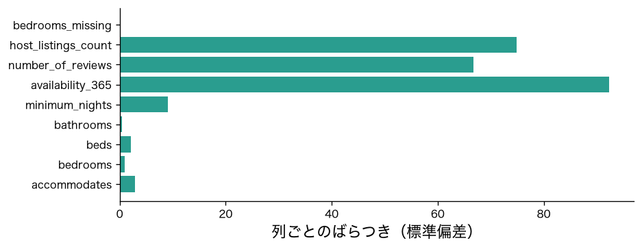

- 予約可能日数は92、掲載数は75。寝室数は0.9、バスルームは0.4（印の列は0.2）

## 目盛りの大きい列が、距離を決める

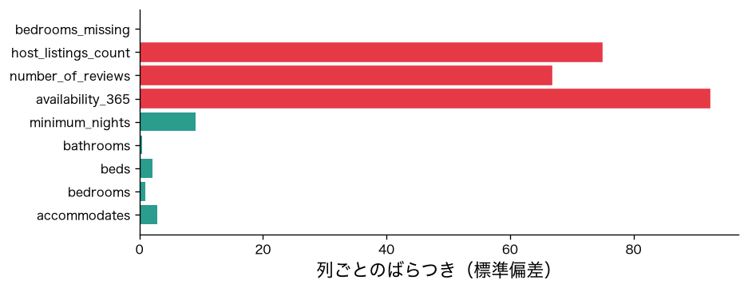

- 距離をそのまま測ると、目盛りの大きい列が「似ている」を決めてしまう

## 答え合わせ：平均0・ばらつき1

```
[-0. -0.  0.  0.  0. -0. -0.  0. -0.]
[1. 1. 1. 1. 1. 1. 1. 1. 1.]
```

- どの列も、平均0・ばらつき1にそろった
- `-0.`は、ごく小さなマイナスを丸めた値。0と同じ

## 答え合わせ：TODO③

```
8315 円
```

- 外れ幅は、9,526円から8,315円に縮んだ
- 3節の式（8,807円）も追い越した

## StandardScalerと一致

```python
sc = StandardScaler().fit(X_tr)
Z_te_sc = sc.transform(X_te)                     # StandardScaler で
print(np.allclose(Z_te_sc, standardize(X_te, mean_tr, std_tr)))
```

- `True`。自分の関数と、scikit-learnの道具が同じ答え

## 線形回帰では、変わらない

- 線形回帰は、係数で目盛りを吸収する。標準化しても予測は同じ
- 距離を使うKNNでは、結果が大きく変わる

# 6. 順番を守る

## 物差しは、どこで決めた？

- 3節の中央値も、5節の平均と標準偏差も、訓練データだけで決めた
- もし、テストも含めた全データで決めたら？

## データリーク

- テストの情報が、前処理を通して学習に漏れる
- 本番の問題を、こっそり過去問に混ぜるようなもの

## お手本：前処理を1つの関数に

```python
def prep(base, df_in):
    med = base[num].median()                 # 補う値は base で決める
    Xb = base[num].fillna(med).values
    X = df_in[num].fillna(med).values
    return standardize(X, Xb.mean(axis=0), Xb.std(axis=0))
```

- 役割：物差しを`base`で決め、`df_in`を整える

## 関数の中で、関数を呼ぶ

```python
    return standardize(X, Xb.mean(axis=0), Xb.std(axis=0))
```

- `prep`の中で、5節の`standardize`を呼んでいる
- 小さな関数を組み合わせて、大きな処理を作る

## お手本：正しい順番で使う

```python
Z_tr = prep(tr, tr)          # 正しい順番：物差しは訓練で
Z_te = prep(tr, te)
knn_ok = KNeighborsRegressor(n_neighbors=10).fit(Z_tr, y_tr)
print('訓練で決めた :', mae(y_te, knn_ok.predict(Z_te)), '円')
```

## 変えてみる：全データで決めると

```python
Z_tr_l = prep(df, tr)        # NG：物差しを全データで決めた
Z_te_l = prep(df, te)
knn_leak = KNeighborsRegressor(n_neighbors=10).fit(Z_tr_l, y_tr)
print('全データで決めた:', mae(y_te, knn_leak.predict(Z_te_l)), '円')
```

- 最初の引数を、`tr`から`df`に変えるだけ

## やってみよう：6節

- 6節のお手本と「変えてみる」のセルを実行する
- 2つの外れ幅は、どれくらい違うか？

動画の人は、ここで一時停止。

## 答え合わせ：差は、ごくわずか

```
訓練で決めた   : 8315 円
全データで決めた: 8322 円
```

- 訓練で決めると8,315円、全データで決めると8,322円
- 2万件以上あると、中央値や平均はほとんど動かない

## それでも、訓練だけで決める

- データが少ないとき、テストの期間だけ傾向が違うときは、差が大きく出る
- 差が出るかどうかにかかわらず、前処理は訓練だけで決める

# 7. 1泊いくら？

## 前処理がそろった。値付けへ

- 6節で、補い方と物差しを`prep`1つにまとめた
- いちばん外れ幅の小さい、標準化したKNNで値付けする

## お手本：新しい部屋を値付けする

```python
my_room = pd.DataFrame([{'accommodates': 4, 'bedrooms': 2, 'beds': 2,
                         'bathrooms': 1, 'minimum_nights': 2,
                         'availability_365': 200,
                         'number_of_reviews': 0,
                         'host_listings_count': 1,
                         'bedrooms_missing': 0}])
price = knn_ok.predict(prep(tr, my_room))[0]
print(round(price), '円')
```

- 新しい部屋にも、訓練で決めた同じ補い方・同じ物差しを当てる
- 寝室数は分かっているので、欠けていた印は0

## TODO④：自分の部屋を値付けする

```python
# TODO: my_room の条件を変えた部屋を作り、prep と knn_ok で値付けする
# ヒント: room2 = my_room.assign(accommodates=2, bedrooms=1, beds=1)
#         のように変えられる
...
```

## やってみよう：7節とTODO④

- 7節のお手本のセルを実行する
- TODO④：定員や寝室数を自分で決めて、値付けする

動画の人は、ここで一時停止。

## 答え：およそ3万1千円

```
31437 円
```

1泊およそ3万1千円。

## この答えも、外れうる

```
31437 円
```

- まだ見ていない部屋全体での外れ幅は、平均8千円ほど

## 答え合わせ：TODO④ の例

```
17109 円
```

- 定員2人・寝室1・ベッド1なら、約1万7千円

## まだ言えないこと①：外した部屋

- 10万円を超える部屋を外してよかったのか
- 戻すと、外れ幅はどうなるのか

## まだ言えないこと②：物差し

- 外れ幅の平均だけで、式を選んでよいか
- 大外れを重く見る物差しもある

## まだ言えないこと③：地区

- 地区で料金は2倍近く違うのに、今の値付けには地区が入っていない

# まとめ

## 今日の歩み

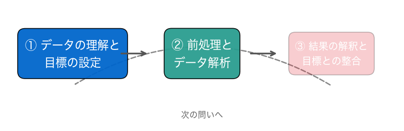

外す行を決める → 欠けを戻す・補う → 番号の危うさ → 目盛りをそろえる → 順番を守る

## 今日の要点

- 外す行は、目標から理由を説明でき、線を書き残せるときに外す
- 欠けた値は、理由を先に確かめる。別の列から戻せるなら戻す
- 補うなら訓練の中央値で。補った値は推測なので、欠けていた印を残す
- 文字の区分に番号を振ると、振り方しだいで係数の向きまで変わる
- 距離を使うKNNでは、標準化でずっとよく当たるようになる
- 補う値も物差しも、訓練だけで決める
- Python：`def`で関数を作る。引数が入力、`return`が出力

## 課題の出し方

- ノートの最後の「課題（提出）」に取り組む
- 応用②の答えと応用③の文章を、LACSに入力して提出（＝出席。期限なし）
- AIを使ってもよい。何を聞いて、どう直したかを1行書く

## 次回予告：物差しを選ぶ

- 場面は、住宅の査定
- 高い家に引っぱられない当て方と、大外れを重く見る物差しを比べる

## 次回の問い

「この家は、なぜこの値段なのか」を説明する式を、どの物差しで選び、どう読むか。

## このあと：課題へ

ノートの「課題（提出）」へ。欠けた値を平均で補って、中央値と比べます。